# R Notebook 3 - masking NetCDF data

Hello, and welcome to the final R climate notebook. In the first R notebook we explained what variables and function are (where we store climate data and how we operate on climate data, respectively), we described using simple mathematical operations on variables (which therefore allows us to do useful things to our data, e.g. such as change units - if you have a matrix of temperatures in degrees Celsius in a variable called temp, then temp+273.15 would change every temperature in temp to Kelvin), and we described how to plot simple time series data. In the second R notebook we explained the NetCDF file format and how we work with it in R, including the standard workflow of opening the file, viewing the header (metadata), extracting variables, extracting attributes, and closing the file. We then explained slicing out a specific time slice to make a map. We flipped the time slice, showed ways to plot with different colour palettes, and how to save plots.

In this final notebook, we will read some data from a NetCDF file and make a difference map to show the changes between two different time slices. We will then use our subsetting skills to slice our data into regions of interest, e.g. just the tropics or just a longitude slice. We then cover how to use a mask in a separate NetCDF file to mask out areas and regions of arbitrary shape, allowing us to subset geographic regions such as individual continents, or individual habitat areas. We also show how to find summary statistics for any of these subsetted areas. Finally, we show how to extract a time series at a particular location, so we can see how a variable has changed over time. Let’s get started!

## Read in data from NetCDF

We start by reading in our NetCDF data. We use the setwd() function to set the working directory to the location of our saved NetCDF file. We then use the library() function to load the ncdf4 package so we can open the NetCDF file. We use the nc_open() function to open a connection to the NetCDF file and save it to a variable. We use print() to view the header of the NetCDF file, and the ncvar_get() function to extract the lat, lon, time and yield_mai variables - which we found the names for from the print() function. We then get the attributes we want with the ncatt_get() function, and close the file connection with the nc_close() function. This was all explained in detail in the previous R notebook. Finally we change the _FillValues in the NetCDF file to NAs so R does not plot them, and extract the first yield slice and flip it upside down, ready for plotting.

```r
## Use the workflow from R notebook 2 to read in the NetCDF file
# Set the working directory to where the data files are saved
setwd("~/Documents/scratch/R_netcdf")
# Load the ncdf4 library into R. (note, we installed this with install.packages() in Notebook 2)
library("ncdf4")
# Open a file connection to the NetCDF file
ncfile <- nc_open("lpj-guess_agmerra_fullharm_yield_mai_global_annual_1980_2010_C360_T0_W0_N60_A0_1deg.nc4")
# Print the NetCDFs header
print(ncfile)
```

```
File lpj-guess_agmerra_fullharm_yield_mai_global_annual_1980_2010_C360_T0_W0_N60_A0_1deg.nc4 (NC_FORMAT_NETCDF4_CLASSIC):

     1 variables (excluding dimension variables):
        double yield_mai[lon,lat,time]
            units: t ha-1 yr-1 (dry matter)
            _FillValue: 1e+20
            missing_value: 1e+20

     3 dimensions:
        time  Size:31   *** is unlimited ***
            standard_name: time
            units: years since 1980-01-01 00:00:00
            calendar: standard
            axis: T
        lon  Size:360
            standard_name: longitude
            long_name: longitude
            units: degrees_east
            axis: X
        lat  Size:180
            standard_name: latitude
            long_name: latitude
            units: degrees_north
            axis: Y

    10 global attributes:
        _NCProperties: version=1|netcdflibversion=4.4.1.1|hdf5libversion=1.10.1
        CDI: Climate Data Interface version 1.9.3 (http://mpimet.mpg.de/cdi)
        Conventions: CF-1.6
        history: Mon Mar 26 10:05:34 2018: cdo remapbil,./1.grid.asc -setgrid,05.grid.asc lpj-guess_agmerra_fullharm_yield_mai_global_annual_1980_2010_C360_T0_W0_N60_A0.nc4 lpj-guess_agmerra_fullharm_yield_mai_global_annual_1980_2010_C360_T0_W0_N60_A0_1deg.nc4
        institution: Lund University, Sweden; University of Birmingham, UK
        title: LPJ-GUESS output
        comment: Crop model output for AgGRID Phase II
        contact: Stefan Olin, stefan.olin@nateko.lu.se; Thomas Pugh, t.a.m.pugh@bham.ac.uk
        version: Version 2: 13-Oct-2017
        CDO: Climate Data Operators version 1.9.3 (http://mpimet.mpg.de/cdo)
```

```r
# Extract variables from the NetCDF file
lat=ncvar_get(ncfile, 'lat')
lon=ncvar_get(ncfile,'lon')
time=ncvar_get(ncfile, "time")
yield = ncvar_get(ncfile, 'yield_mai')
# Extract attributes from the NetCDF file
yield_units=ncatt_get(ncfile, "yield_mai", "units")
yield_fillvalue <- ncatt_get(ncfile,"yield_mai","_FillValue")
# Close the NetCDF file connection
nc_close(ncfile)
# replace netCDF fill values with NA's
yield[yield==yield_fillvalue$value] <- NA
# Extract the first time slice from the NetCDF file as a matrix, and store in a variable called first_yield_slice.
first_yield_slice = yield[,180:1,1]
```

Lets start by using the image function to see what the data looks like.

```
no non-missing arguments to min; returning Infno non-missing arguments to max; returning -Inf
```

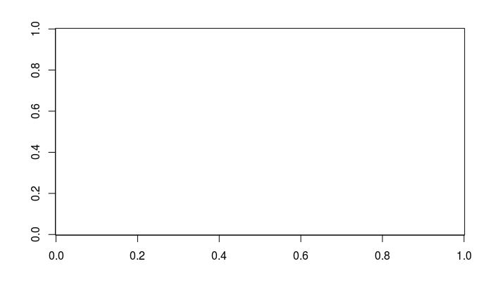

```r
image(first_yield_slice)
```

Hmm, that’s a bad start. The map seems to be empty - i.e. we seem to have no data in the slice. This normally means we have done something wrong, but there are occasions when it’s just a dodgy file in one way or another.

Let’s try checking the dimensions of the file to see if we can find out what is wrong.

```r
dim(first_yield_slice)
```

```
[1] 360 180
```

Hmm, the dimensions seem to be what we are expecting. Maybe it’s just a dodgy file. Let’s try the second time slice instead.

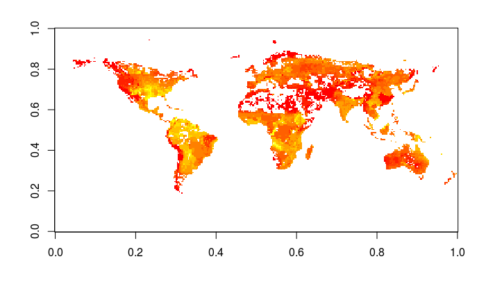

```r
first_yield_slice = yield[,180:1,2]
image(first_yield_slice)
```

Oh. The second slice is fine. Must just be a dodgy file. *Note that I have kept this example in this R notebook to show what working with data for the first time is like. I had a problem, so I tried to work out what the problem was by trying a couple of different functions.* This is totally normal when working with data in science. Anyway, let’s carry on.

## Making a difference map

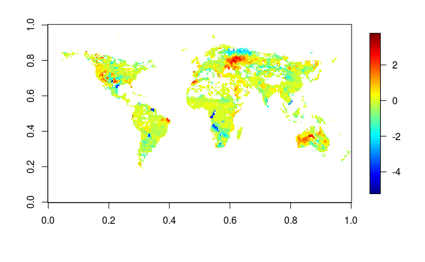

```r
# Let's make a difference map by subtracting one time slice from another.
# Load the fields package for plots with a colourbar. We installed the fields package with install.packages() in Notebook 2.
library("fields")
# Select the second time slice and store in a variable called yield2. Note the 180:1 in the lattitude space, which flips the matrix (as it is upside down in the yield variable)
yield2 = yield[,180:1,2]
# # Select the third time slice and store in a variable called yield3. Note the 180:1 in the lattitude space, which flips the matrix (as it is upside down in the yield variable)
yield3 = yield[,180:1,3]
# Find the difference between the two matrixs of data.
yield_difference = yield3 - yield2
# Make a plot of the difference
image.plot(yield_difference)
```

Hmm. The map is pretty to look at, and the data is pretty cool. However it would be much easier to understand what is happening globally with a polar colour palette - i.e. one that goes from one colour to white to another colour. The RColorBrewer package we introduced in the last notebook has several of polar colour palettes, including a very fetching red - white - blue one:

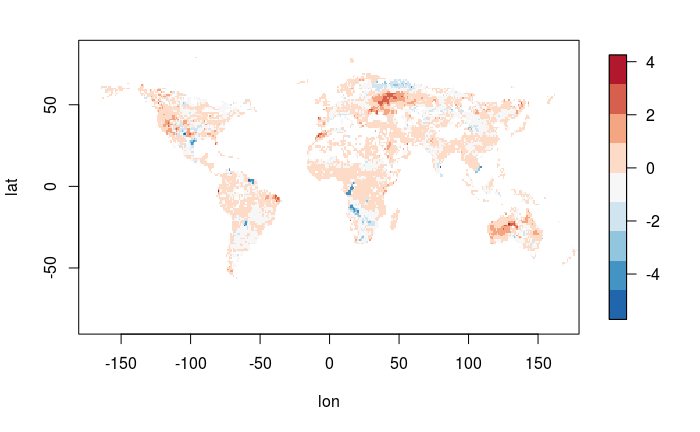

```r
library("RColorBrewer")
image.plot(lon, lat, yield_difference, col=rev(brewer.pal(9,'RdBu')))
```

Sometimes there is a lot of increase but almost no decrease in something over time (or the opposite, lots of decrease and little increase). Plotting this kind of data can end up with the white of the colour palette not being centered over 0 (remember if we are looking at a difference map made by subtracting one time slice from another a value of 0 means there is no change, so this is important for understanding the data!). A polar colour palette such as what we are using needs to be centered at zero, otherwise it gives a very skewed message. A useful cheat to handle this in R is to make a single square in our yield_difference matrix the positive largest absolute value in the whole matrix, and another square the negative largest absolute value in the whole matrix. This means the colourbar will be perfectly centered at 0, because the colourbar fit’s itself between the smallest and largest values. However note, *you shouldn’t do this before extracting any summary statistics* about the data (because we are actually changing two values of the data), and also *you shouldn’t do this if the data is low resolution*, as you may be able to actually see the values you have changed.

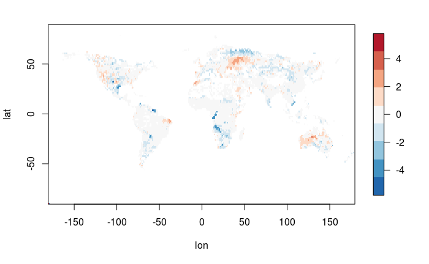

```r
# Cheat at centering the colourbar at 0 by making the lowest right hand corner the posative maximum absolute value, and making the square next to it the negative maximum absolute value. Do not do this before taking summary statistics of the data, as we are actually changing the data to make it plot how we want it to. Also do not use with low resolution data, as you may be able to see the values you have changed.
yield_difference_altered = yield_difference
yield_difference_altered[1,1] = max(abs(yield_difference_altered), na.rm=T)
yield_difference_altered[2,1] = -max(abs(yield_difference_altered), na.rm=T)
image.plot(lon, lat, yield_difference_altered, col=rev(brewer.pal(9,'RdBu')))
```

OK this is cool. Now that we’ve set the colour bar we can see that between time slices 2 and 3, actually most of the world only changes a tiny bit. But certain regions seem to be changing much more.

## Summary statistics on data

You might well want to take summary statistics for a grid of data. This is incredibly easy in R. Say, for example, you wanted to find the mean of our yield_difference, i.e. we wanted to find the average global change between slices 2 and 3:

```r
mean(yield_difference)
```

```
[1] NA
```

Oops, we forgot the na.rm=T function argument. Remember many functions in R return NA if there are *any* NAs in the data, as a warning there are NAs there. Let’s rerun it:

```r
mean(yield_difference, na.rm=T)
```

```
[1] -0.1076436
```

Similarly, lets find some other summary statistics for our slice:

```r
median(yield_difference, na.rm=T)
```

```
[1] -0.0283
```

```r
sd(yield_difference, na.rm=T)
```

```
[1] 0.7540891
```

```r
max(yield_difference, na.rm=T)
```

```
[1] 3.6991
```

```r
min(yield_difference, na.rm=T)
```

```
[1] -5.1557
```

## Subset only equatorial regions

You might want to find the mean (average) yield over a smaller area than the whole world. This is easy to do.

[figure not shown]

## Subset only polar regions

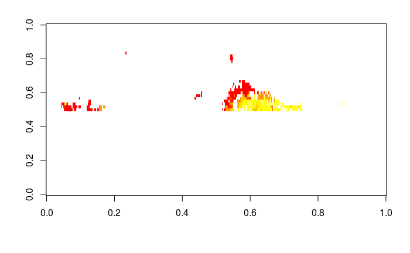

```r
# The polar regions are regions above 60 degrees north and below 60 degrees south lattitude. However remember our grid goes from 0 to 180 at the sides, not from -90 to +90. Therefore to get the correct locations we do 90-[lattitude of interest] and 90+[lattitude of interest]
polar_south = 90 - 60
polar_north = 90 + 60
# use the square bracket notation to subset our grid of data. Leave the first space before the comma blank to select all longitudes. The second space is a little complex. We use 1:polar_south to get the south polar region, and polar_north:180 to get the north polar region. We then use the concatenate function "c()" to stick the two blocks of data together to allow subsetting. This is a little complex I realize, but just copy and paste this code if you need it.
polar_yield_slice = temp_slice[ , c(1:polar_south, polar_north:180) ]
# Make a quick plot of the data. Note it will look weird because Antarctica and lots of Arctica Canada and Greenland don't appear to have been modelled. However you can see the top of Norway and parts of Russia.
image(polar_yield_slice)
```

## Subset Longitude slices

The exact same idea can be used to extract a longitude slice. (In fact, hopefully you are starting to see the same ideas about how to select subsets of data over and over again).

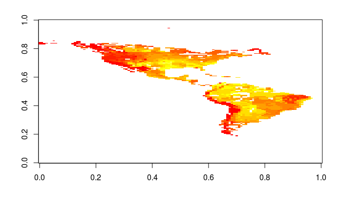

```r
# The longitude bounds for north and south America are roughly 160 degrees west to 30 degrees west. However remember our matrix goes from 0 at the left hand side to 360 at the right hand side, rather than the more familliear -180 to +180. Therefore we need to do 180-160 for 160 degrees west and 180-30 for 30 degrees west.
lat1 = 180 - 150
lat2 = 180 - 30
# Select the longitude slide using the lat1:lat2 colon notation to select the range of values. Leave the space after the comma blank to select all values for lattitude.
polar_yield_slice = temp_slice[lat1:lat2, ]
# Make a quick plot of the lattitude slice.
image(polar_yield_slice)
```

## Combining it - subset a box around a country of interest

You might have guessed that if we can subset data with latitude and with longitude (and with time - every time we have taken a time slice we have just be subsetting by time!), then we can combine subsetting latitude and longitude to select a particular region.

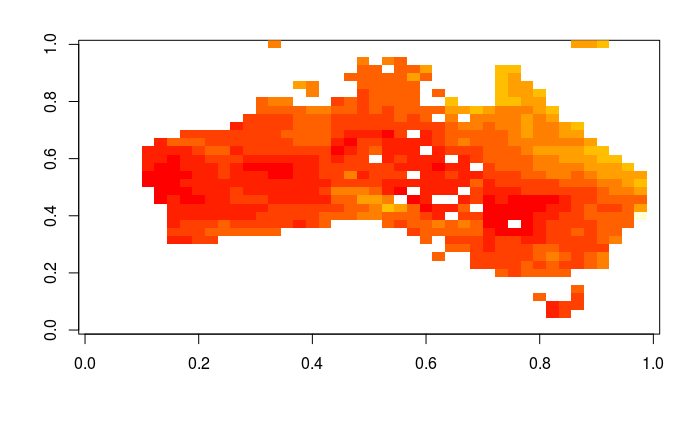

```r
australia_yield_slice = temp_slice[290:335 , 45:80]
image(australia_yield_slice)
```

## Subset using a mask

So we can now subset any type of rectangular box or slice we want from out matrix of data that we extracted from a NetCDF file. But what if we want an area more complex than a rectangular box? This is best done with a mask. A mask is normally a NetCDF file filled with the number 1 everywhere in a region we want to extract, and filled with NA everywhere else. If we extract our mask into a variable, and then multiply our mask by our data, then everywhere multiplied by 1 will stay the same, while everywhere filled with NA will become NA. This is because in R, anything multiplied by NA becomes NA. (This is kinda like how in maths, anything multiplied by 0 becomes 0. But 0 can actually have meaning in climate data, so we don’t want to set everywhere outside our mask to zero.).

Let’s quickly see an example. This example is sort of like making out one place we want to get rid of:

```r
pretend_data1 = c(0,1,2,3,4,5)
pretend_mask1 = c(1,1,NA,1,1,1)
pretend_data1 * pretend_mask1
```

```
[1]  0  1 NA  3  4  5
```

Or a similar example, this example is more like making out all of the rest of the world to extract just one country or region:

```r
pretend_data2 = c(0,1,2,3,4,5)
pretend_mask2 = c(NA,NA,NA,1,NA,NA)
pretend_data2 * pretend_mask2
```

```
[1] NA NA NA  3 NA NA
```

Hopefully the idea of masking to get rid of data is pretty clear! Now lets actually do it with a real mask. Here we skip a load of steps in reading the NetCDF as I already know what is in the file. I still print the header of the NetCDF file, as there is almost always some useful information in the header:

```r
ncfile = nc_open("ESA_forest_9regions_v2_1deg.nc")
print(ncfile)
```

```
File ESA_forest_9regions_v2_1deg.nc (NC_FORMAT_NETCDF4_CLASSIC):

     1 variables (excluding dimension variables):
        double region_mask[lon,lat]
            Comment: 1=Tropical broadleaved evergreen, 2=Tropical broadleaved deciduous, 3=Other Tropical (<23 degrees), 4=Temperate broadleaved evergreen, 5=Temperate broadleaved deciduous, 6=Needleleaved evergreen, 7=Needleleaved Deciduous, 8=Broadleaved/Needleaved mixed forest, 9=Other

     2 dimensions:
        lon  Size:360
            standard_name: longitude
            long_name: longitude
            units: degrees_east
            axis: X
        lat  Size:180
            standard_name: latitude
            long_name: latitude
            units: degrees_north
            axis: Y

    8 global attributes:
        _NCProperties: version=1|netcdflibversion=4.4.1.1|hdf5libversion=1.10.1
        CDI: Climate Data Interface version 1.9.3 (http://mpimet.mpg.de/cdi)
        Conventions: CF-1.6
        history: Mon Mar 26 10:11:54 2018: cdo remaplaf,./1.grid.asc -setgrid,05.grid.asc ESA_forest_9regions_v2.nc ESA_forest_9regions_v2_1deg.nc
        Comment: Created based on ESACCI-LC-L4-LCCS-Map-300m-P1Y-2015-v2.0.7.tif using esa_forest_9regions_new_func.m
        Version: 2
        Contact: T. Pugh, t.a.m.pugh@bham.ac.uk
        CDO: Climate Data Operators version 1.9.3 (http://mpimet.mpg.de/cdo)
```

```r
mask = ncvar_get(ncfile, 'region_mask')
nc_close(ncfile)
```

OK, so immediately we have found useful information in the header. The header says:

> double region_mask[lon,lat]  
> Comment: 1=Tropical broadleaved evergreen, 2=Tropical broadleaved deciduous, 3=Other Tropical (<23 degrees), 4=Temperate broadleaved evergreen, 5=Temperate broadleaved deciduous, 6=Needleleaved evergreen, 7=Needleleaved Deciduous, 8=Broadleaved/Needleaved mixed forest, 9=Other

So it seems like this file is a mask for many different regions (in this case forest regions). Each region seems to be filled with a common value, going from 1 to 9. Let’s try plotting the mask to see if we are correct:

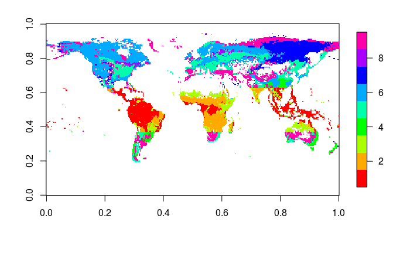

```r
image.plot(mask, col=rainbow(9))
```

Yep, looks like we are correct. However, as we talked about earlier, we preferably want this data mask to be in the form of 1s where we want to extract the data, and NAs everywhere else. Luckily we can do this in 1 line of code in R. Meet the “ifelse()” function. The ifelse() function takes a condition as it’s first argument (for example mask==3, which means select only the places where the mask equals 3), the value to change to when that condition is true as it’s second argument (which will always be 1 for us), and the value to change to when that condition is false as it’s third argument (which will always be NA for us). Let’s see this in action to make a mask for tropical broadleaved deciduous forests, select those by multiplying our data by out new mask, and then making a map of our selected data:

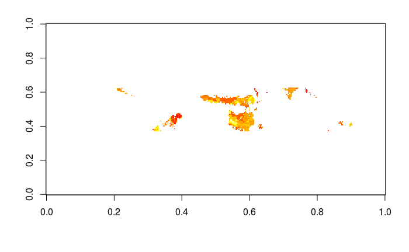

```r
# Make a new mask for tropical broadleaved deciduous forest using the ifelse() function. This line of code makes a matrix where tropical broadleaved deciduous forest are set to 1, while the rest of the matrix is set to NA. This matrix is then saved to the variable tropical_broad_dec_mask.
tropical_broad_dec_mask = ifelse(mask == 2,1,NA)
# Select that data by multiplying the data in first_yield_slice by the mask.
first_yield_slice_tropical_broad = first_yield_slice * tropical_broad_dec_mask
# Make a plot of our subsetted data.
image(first_yield_slice_tropical_broad)
```

And then after we have subsetted/masked/selected (these words all mean the same thing here) our data, we can find summary statistics for it. Don’t forget the na.rm=T (or na.rm=TRUE) function argument!

```r
mean(first_yield_slice_tropical_broad, na.rm = T)
```

```
[1] 3.934901
```

Let’s do a second example, just to show it again.

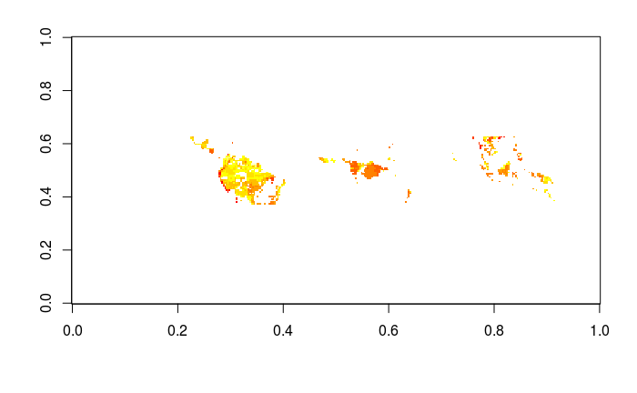

```r
# Make a new mask for tropical broadleaved deciduous forest using the ifelse() function. This line of code makes a matrix where tropical broadleaved deciduous forest are set to 1, while the rest of the matrix is set to NA. This matrix is then saved to the variable tropical_broad_dec_mask.
tropical_broad_ever_mask = ifelse(mask == 1,1,NA)
# Select that data by multiplying the data in first_yield_slice by the mask.
first_yield_slice_tropical_broad_ever = first_yield_slice * tropical_broad_ever_mask
# Make a plot of our subsetted data.
image(first_yield_slice_tropical_broad_ever)
```

## Time series

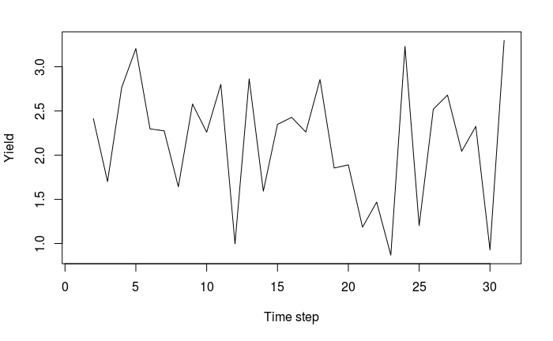

```r
time_series_australia = yield[250,60,]
plot(time_series_australia, type='l', xlab="Time step", ylab='Yield')
```

Or sometimes you might want to make a histogram of the values to see a different way of looking at their spread:

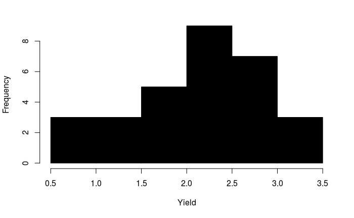

```r
hist(time_series_australia, col='black', main='', xlab='Yield')
```

And we are finished! You can now do a huge amount of things in R. You can manipulate data to change it’s units via simple mathematical operations. You can install and load new packages for free. You can read and work with data files hundreds of times too big to open in excel. You can make and save publication quality maps and graphs. You can select, mask and filter data you want. You can find summary statistics for areas and regions of the world, and you can make several types of plot to summarize it. Well done! I hope you have found this series of R notebooks helpful. Good luck in using these skills for your own work, and enjoy!